# CEMA INTERNSHIP TASK

## Examining the factor variables

### Converting to factor

```r
data$county<-as.factor(data$county)
```

### Generating columns for month and year

```r
data <- data %>%mutate(month_num = month(parse_date_time(period, "my")),month = month.abb[month_num],year = year(parse_date_time(period, "my")))
data <- data %>%select(-month_num)
```

### Investigating the year on year trends of numerical variables

#### Total Dewormed

```r
yr<-data%>%group_by(year)%>%summarise("Total Dewormed"=sum(`Total Dewormed`),"Diarrhoea Cases"=sum(`diarrhoea cases`),"Total underweight 0-<6 months"=sum(`Underweight 0-<6 months`), "Total  Underweight 6-23 monnths"=sum(`Underweight 6-23 months`), "Total underweight 24-59 months"=sum(`Underweight 24-59 Months`), "Total Acute Malnutrition"=sum(`Acute Malnutrition`, na.rm=TRUE),"Total Stunted 6-23 Months"=sum(`stunted 6-23 months`,na.rm=TRUE), "Total Stunted 0-<6 months"=sum(`stunted 0-<6 months`, na.rm=TRUE), "Total Stunted 24-59 Months"=sum(`stunted 24-59 months`, na.rm=TRUE))
data.table(yr)
```

```
##    year Total Dewormed Diarrhoea Cases Total underweight 0-<6 months
## 1: 2021        5718543         1464112                        118597
## 2: 2022        6869240         1559646                        125116
## 3: 2023        3567882          943111                         71381
##    Total  Underweight 6-23 monnths Total underweight 24-59 months
## 1:                        288241.0                       115499.5
## 2:                        382920.6                       171786.0
## 3:                        248524.3                       143804.0
##    Total Acute Malnutrition Total Stunted 6-23 Months Total Stunted 0-<6 months
## 1:                    26358                    121293                     72645
## 2:                    63197                    166386                     73984
## 3:                    42742                    104261                     47821
##    Total Stunted 24-59 Months
## 1:                      42583
## 2:                      59440
## 3:                      52605
```

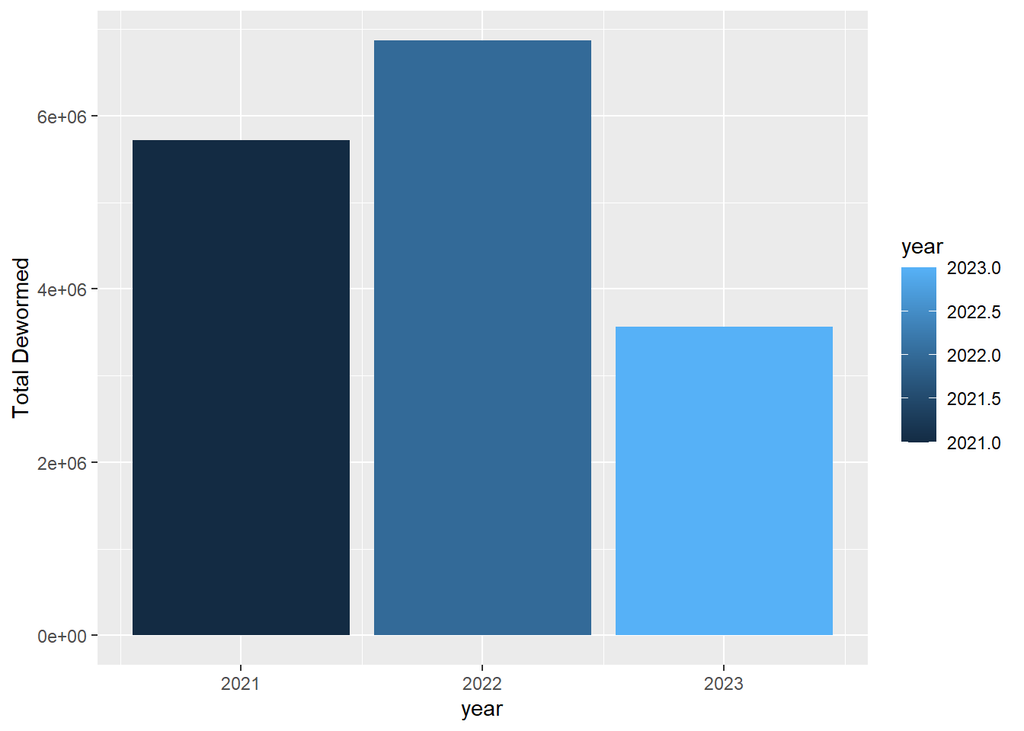

```r
yr<-yr[order(yr$year),]
ggplot(yr, aes(x=year,y=`Total Dewormed`, fill=year))+geom_bar(stat = "identity")
```

The total number of children dewormed increased between the years 2021 and 2022.That upward trend seemed to carry on into 2023, since by June 2023, the numbers had already passed half 2022’s tally.

####Total Diarrhoea Cases

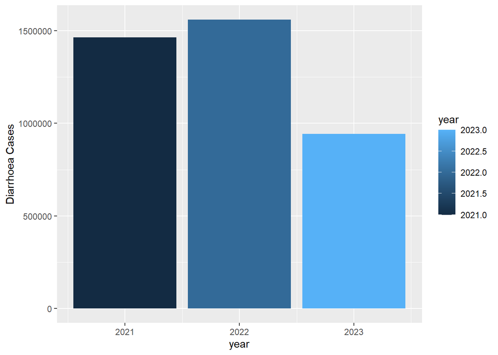

```r
ggplot(yr, aes(x=year,y=`Diarrhoea Cases`, fill=year))+geom_bar(stat = "identity")
```

The total number of diarrhoea cases increased between the years 2021 and 2022.That upward trend seemed to carry on into 2023, since by June 2023, the numbers had already passed half 2022’s tally.

####Total Acute Malnutrition Cases Cases

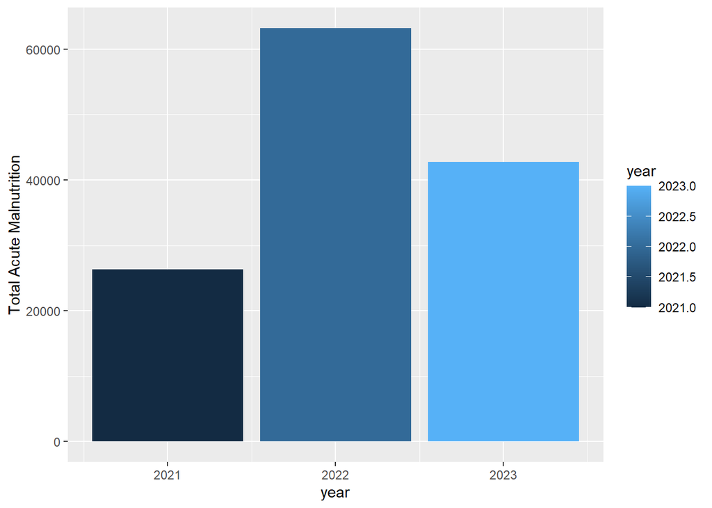

```r
ggplot(yr, aes(x=year,y=`Total Acute Malnutrition`, fill=year))+geom_bar(stat = "identity")
```

The total number of acute malnutrition cases increased between the years 2021 and 2022.That upward trend seemed to carry on into 2023, since by June 2023, the numbers had already passed half 2022’s tally.

####Total Stunted 6-23 Months Cases

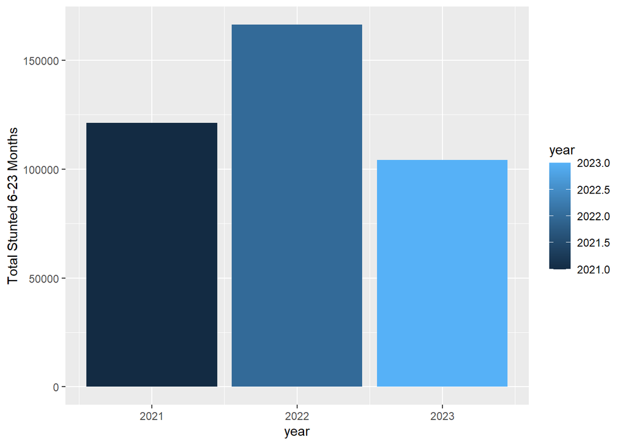

```r
ggplot(yr, aes(x=year,y=`Total Stunted 6-23 Months`, fill=year))+geom_bar(stat = "identity")
```

The total number of Stunted 6-23 Months cases increased between the years 2021 and 2022.That upward trend seemed to carry on into 2023, since by June 2023, the numbers had already passed half 2022’s tally.

####Total Stunted 0-<6 months Cases

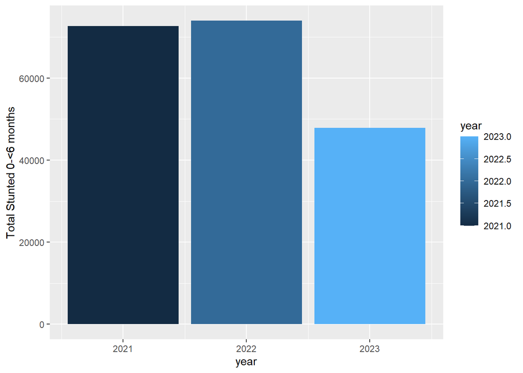

```r
ggplot(yr, aes(x=year,y=`Total Stunted 0-<6 months`, fill=year))+geom_bar(stat = "identity")
```

The total number of Stunted 0-<6 Months cases increased between the years 2021 and 2022.That upward trend seemed to carry on into 2023, since by June 2023, the numbers had already passed half 2022’s tally.

####Total Stunted 24-59 months Cases

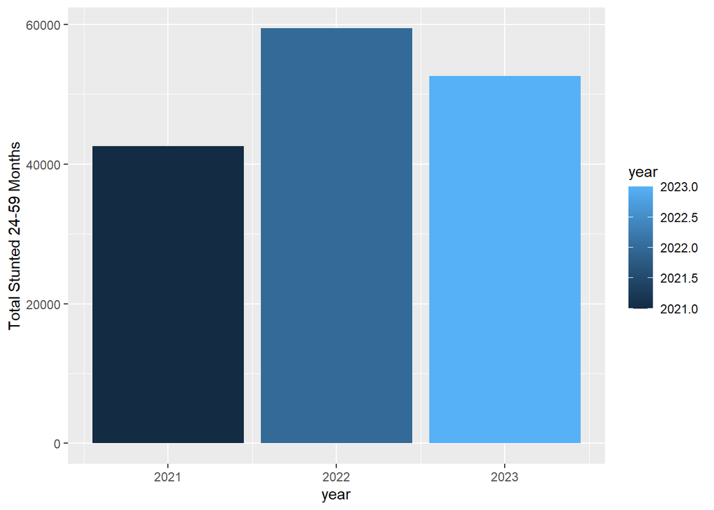

```r
ggplot(yr, aes(x=year,y= `Total Stunted 24-59 Months`, fill=year))+geom_bar(stat = "identity")
```

The total number of Stunted 24-59 Months cases increased between the years 2021 and 2022.That upward trend seemed to carry on into 2023, since by June 2023, the numbers had already passed half 2022’s tally.

####Total underweight 0-<6 months

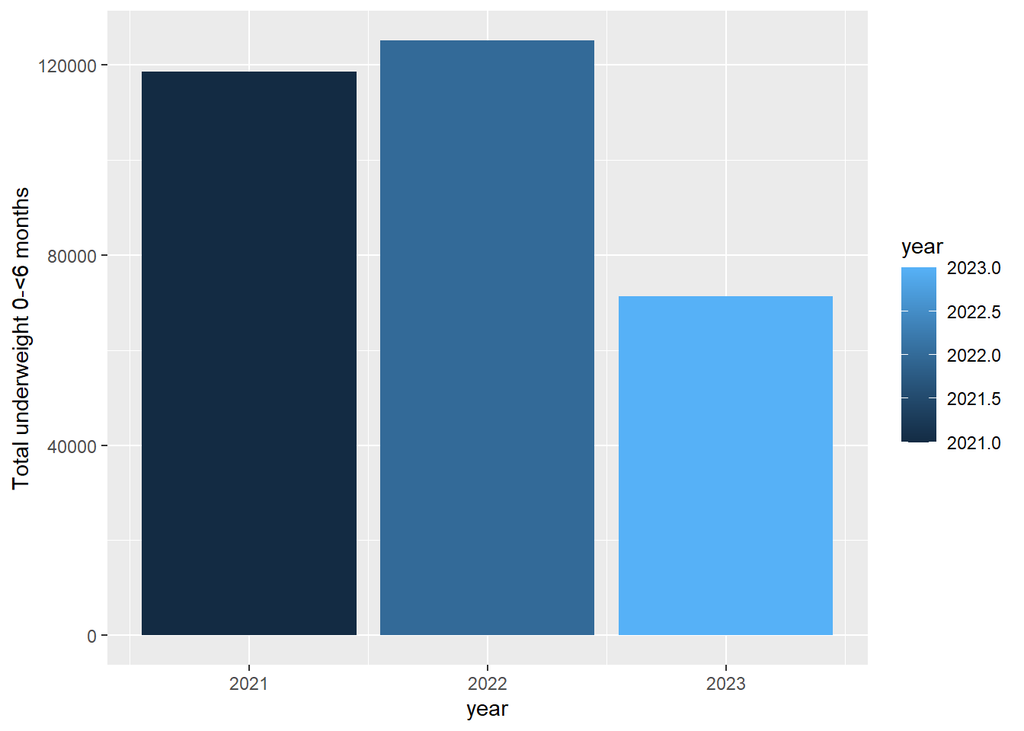

```r
ggplot(yr, aes(x=year,y= `Total underweight 0-<6 months`, fill=year))+geom_bar(stat = "identity")
```

The total number of underweight 0-<6 months cases increased between the years 2021 and 2022.That upward trend seemed to carry on into 2023, since by June 2023, the numbers had already passed half 2022’s tally.

####Total underweight 6-23 months

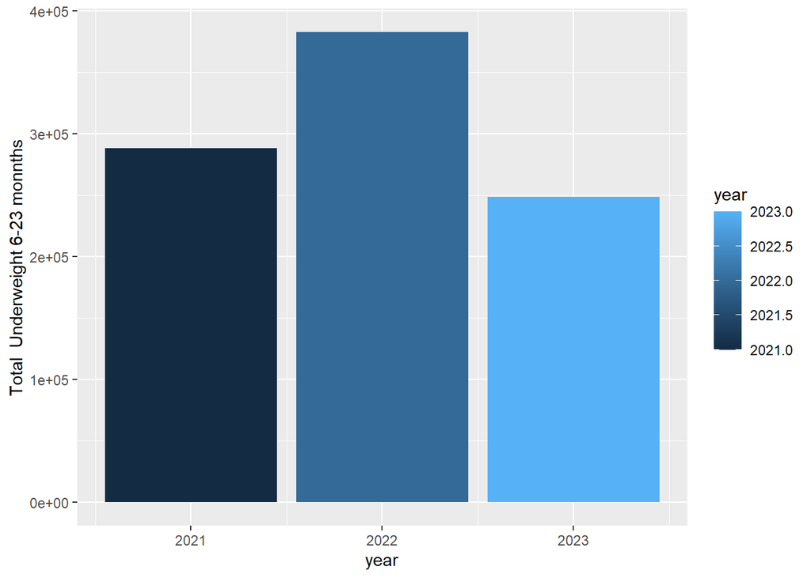

```r
ggplot(yr, aes(x=year,y= `Total  Underweight 6-23 monnths`, fill=year))+geom_bar(stat = "identity")
```

The total number of underweight 6-23 months cases increased between the years 2021 and 2022.That upward trend seemed to carry on into 2023, since by June 2023, the numbers had already passed half 2022’s tally.

####Total underweight 24-59 months

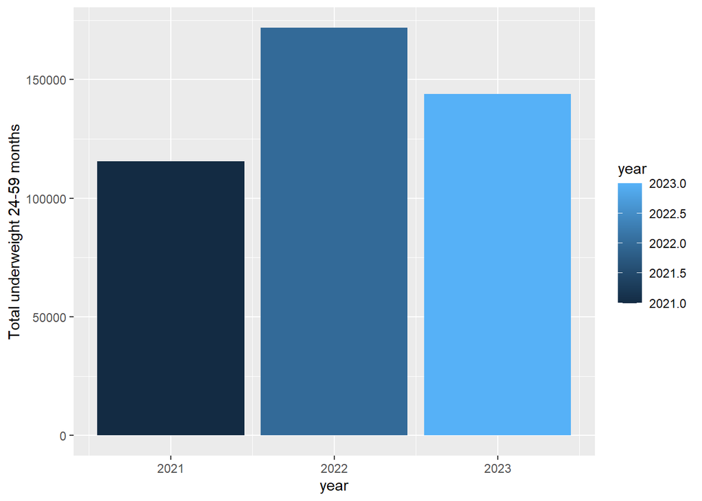

```r
ggplot(yr, aes(x=year,y= `Total underweight 24-59 months`, fill=year))+geom_bar(stat = "identity")
```

The total number of underweight 24-59 months cases increased between the years 2021 and 2022.That upward trend seemed to carry on into 2023, since by June 2023, the numbers had already passed half 2022’s tally.

### Numerical Variable Averages by Month

```r
mt<-data%>%group_by(month)%>%summarise("Average Dewormed"=mean(`Total Dewormed`),"Average Diarrhoea Cases"=mean(`diarrhoea cases`),"Average underweight 0-<6 months"=mean(`Underweight 0-<6 months`), "Average  Underweight 6-23 months"=mean(`Underweight 6-23 months`), "Average underweight 24-59 months"=mean(`Underweight 24-59 Months`), "Average Acute Malnutrition"=mean(`Acute Malnutrition`, na.rm=TRUE),"Average Stunted 6-23 Months"=mean(`stunted 6-23 months`,na.rm=TRUE), "Average Stunted 0-<6 months"=mean(`stunted 0-<6 months`, na.rm=TRUE), "Average Stunted 24-59 Months"=mean(`stunted 24-59 months`, na.rm=TRUE))
mt <- arrange(mt, match(month, month.abb))
data.table(mt)
```

```
##     month Average Dewormed Average Diarrhoea Cases
##  1:   Jan         4510.078                2794.234
##  2:   Feb         4999.681                2984.617
##  3:   Mar         5267.482                3240.957
##  4:   Apr         4874.518                2696.936
##  5:   May        20516.404                3198.177
##  6:   Jun        26928.397                2956.929
##  7:   Jul         4467.840                2438.160
##  8:   Aug         4421.798                2524.202
##  9:   Sep         4944.319                2605.011
## 10:   Oct         6328.819                2459.723
## 11:   Nov        32424.574                2721.787
## 12:   Dec        18636.585                2644.074
##     Average underweight 0-<6 months Average  Underweight 6-23 months
##  1:                        192.8865                         574.1348
```

[output cut: 50 more lines]

#### Visualizing the above information

```r
library(reshape2)
```

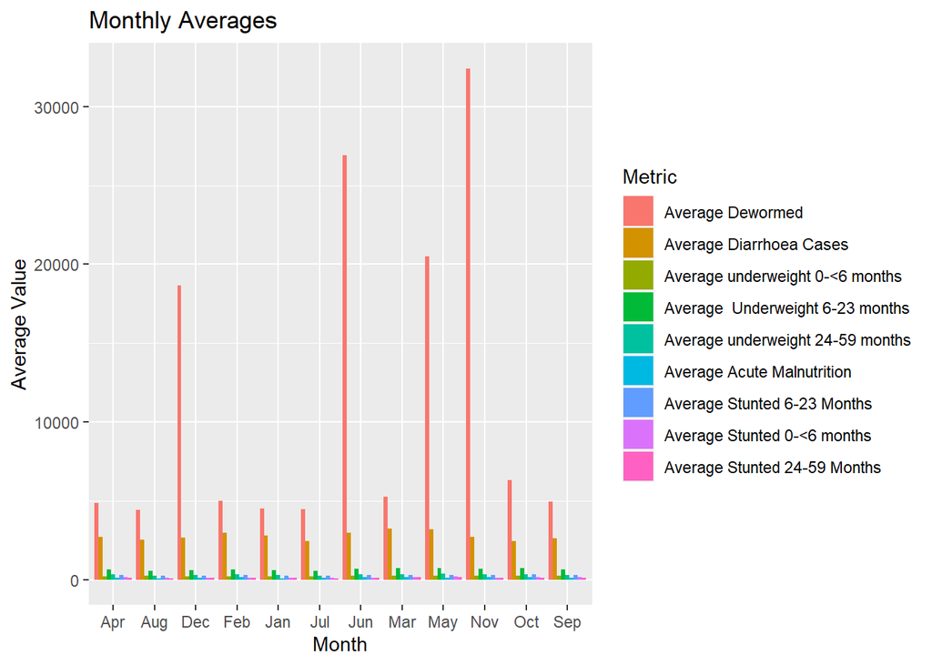

```r
mt_long <- melt(mt, id.vars = "month")

ggplot(mt_long, aes(x = month, y = value, fill = variable)) +geom_bar(stat = "identity", position = "dodge") +labs(title = "Monthly Averages",x = "Month",y = "Average Value",
       fill = "Metric")
```

### Summaries of The Metrics by County

```r
ct<-data%>%group_by(county)%>%summarise("Total Dewormed"=sum(`Total Dewormed`),"Diarrhoea Cases"=sum(`diarrhoea cases`),"Total underweight 0-<6 months"=sum(`Underweight 0-<6 months`), "Total  Underweight 6-23 monnths"=sum(`Underweight 6-23 months`), "Total underweight 24-59 months"=sum(`Underweight 24-59 Months`), "Total Acute Malnutrition"=sum(`Acute Malnutrition`, na.rm=TRUE),"Total Stunted 6-23 Months"=sum(`stunted 6-23 months`,na.rm=TRUE), "Total Stunted 0-<6 months"=sum(`stunted 0-<6 months`, na.rm=TRUE), "Total Stunted 24-59 Months"=sum(`stunted 24-59 months`, na.rm=TRUE))
data.table(ct)
```

```
##                     county Total Dewormed Diarrhoea Cases
##  1:         Baringo County         317901           73523
##  2:           Bomet County          49671           71548
##  3:         Bungoma County         439128           92433
##  4:           Busia County         131360           50694
##  5: Elgeyo Marakwet County         203233           60364
##  6:            Embu County         268790           29336
##  7:         Garissa County         320556           65146
##  8:        Homa Bay County         229969           54505
##  9:          Isiolo County         102752           33148
## 10:         Kajiado County         509732          117741
## 11:        Kakamega County         507825          111957
## 12:         Kericho County          57840           86709
## 13:          Kiambu County         552724          155463
## 14:          Kilifi County         796537          229190
```

[output cut: 230 more lines]

```r
ct$cnty<-ct$county
ct$cnty<-gsub(" county$", "", ct$cnty, ignore.case = TRUE)
ct$cnty<-gsub("Elgeyo Marakwet", "Elgeyo-Marakwet", ct$cnty, ignore.case = TRUE)
ct$cnty<-gsub("Muranga", "Murang'a", ct$cnty, ignore.case = TRUE)
ct$cnty<-gsub("Tharaka Nithi", "Tharaka-Nithi", ct$cnty, ignore.case = TRUE)
```

### Map Showing the Number of Children Dewormed by County

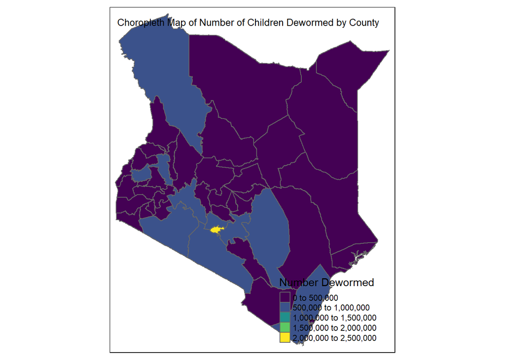

```r
# Load required libraries
library(maptools)
library(raster)
library(tmap)
library(rgdal)
# Get Kenya's administrative boundary data
Kenya <- getData("GADM", country = "KE", level = 0)
Kenya1 <- getData("GADM", country = "KE", level = 1)
Kenya1_UTM <- spTransform(Kenya1, CRS("+init=EPSG:32737"))

# Assuming ct is your dataframe with county-level data, and "NAME_1" is the column containing county names
ct$NAME_1 <- toupper(ct$cnty) # Ensure the county names are in the same format as in Kenya1_UTM@data

# Merge the ct dataframe with Kenya1_UTM@data based on county names
Kenya1_UTM@data <- merge(Kenya1_UTM@data, ct, by.x = "NAME_1", by.y = "cnty", all.x = TRUE)

# Plot the choropleth map using tmap with Kenya1_UTM@data
tm_shape(Kenya1_UTM) +tm_borders() +tm_fill("Total Dewormed", title = "Number Dewormed", palette = "viridis") +tm_layout(title = "Choropleth Map of Number of Children Dewormed by County",legend.position = c("right", "bottom"))
```

### Map Showing the Number of Diarrhoea Cases by County

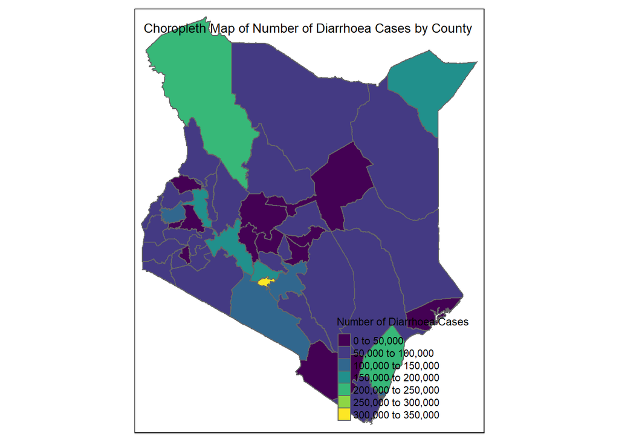

```r
tm_shape(Kenya1_UTM) +tm_borders() +tm_fill("Diarrhoea Cases", title = "Number of Diarrhoea Cases ", palette = "viridis") +tm_layout(title = "Choropleth Map of Number of Diarrhoea Cases by County",legend.position = c("right", "bottom"))
```

### Map Showing the Total Number of Underweight Children between 0-<6 Months by County

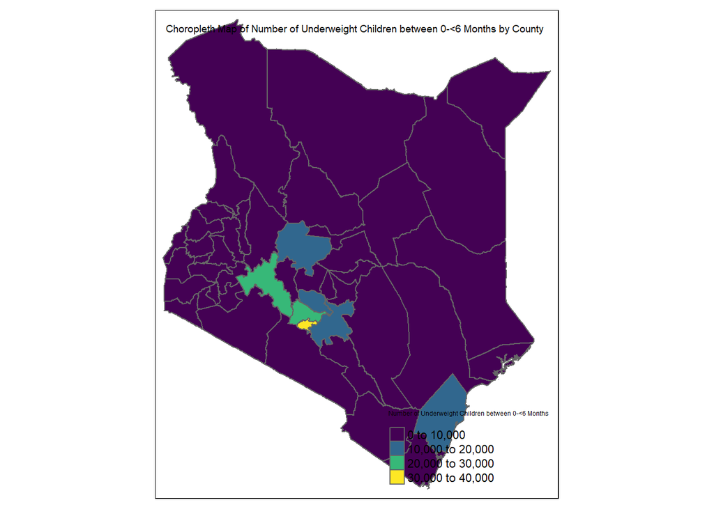

```r
tm_shape(Kenya1_UTM) +tm_borders() +tm_fill("Total underweight 0-<6 months", title = "Number of Underweight Children between 0-<6 Months ", palette = "viridis") +tm_layout(title = "Choropleth Map of Number of Underweight Children between 0-<6 Months by County",legend.position = c("right", "bottom"))
```

### Map Showing the Total Number of Underweight Children between 6-23 Months by County

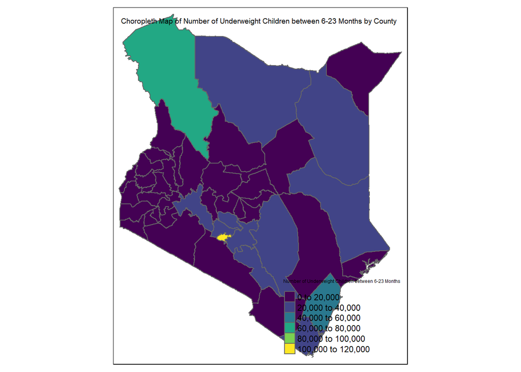

```r
tm_shape(Kenya1_UTM) +tm_borders() +tm_fill("Total  Underweight 6-23 monnths", title = "Number of Underweight Children between 6-23 Months ", palette = "viridis") +tm_layout(title = "Choropleth Map of Number of Underweight Children between 6-23 Months by County",legend.position = c("right", "bottom"))
```

### Map Showing the Total Number of Underweight Children between 24-59 Months by County

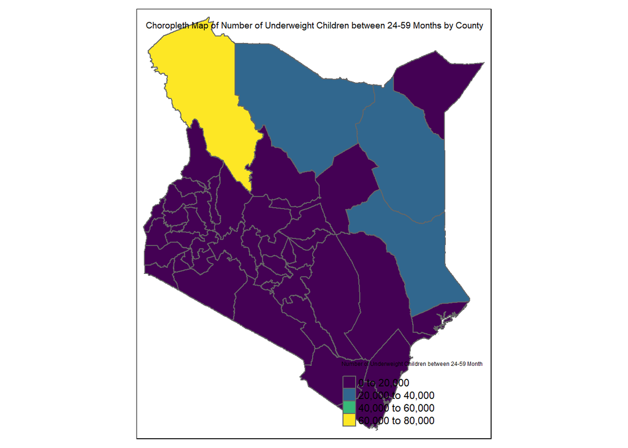

```r
tm_shape(Kenya1_UTM) +tm_borders() +tm_fill("Total underweight 24-59 months", title = "Number of Underweight Children between 24-59 Months ", palette = "viridis") +tm_layout(title = "Choropleth Map of Number of Underweight Children between 24-59 Months by County",legend.position = c("right", "bottom"))
```

### Map Showing the Total Number of Acute Malnutrition Incidences by County

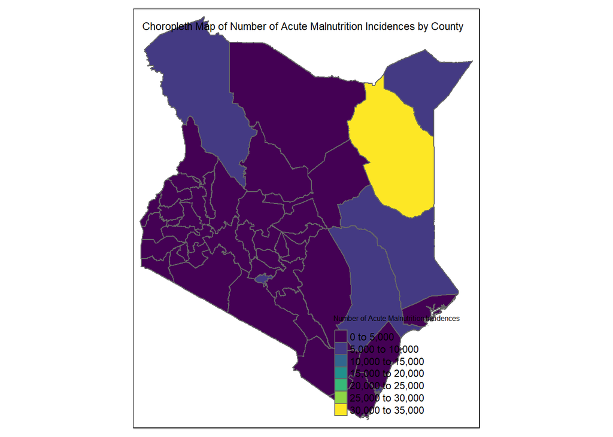

```r
tm_shape(Kenya1_UTM) +tm_borders() +tm_fill("Total Acute Malnutrition", title = "Number of Acute Malnutrition Incidences ", palette = "viridis") +tm_layout(title = "Choropleth Map of Number of Acute Malnutrition Incidences by County",legend.position = c("right", "bottom"))
```

### Map Showing the Total Number of Stunted Children Between 6-23 Months by County

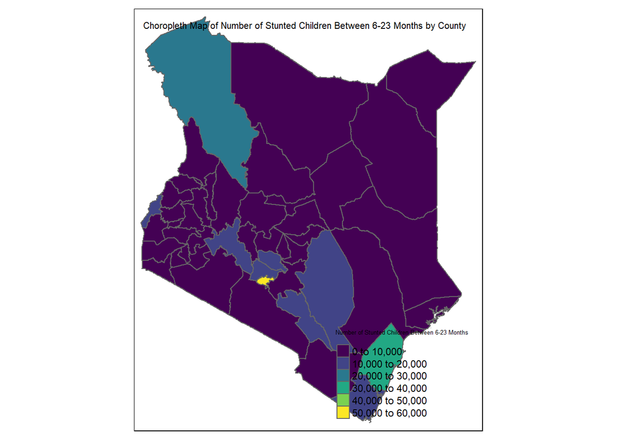

```r
tm_shape(Kenya1_UTM) +tm_borders() +tm_fill("Total Stunted 6-23 Months", title = "Number of Stunted Children Between 6-23 Months ", palette = "viridis") +tm_layout(title = "Choropleth Map of Number of Stunted Children Between 6-23 Months by County",legend.position = c("right", "bottom"))
```

### Map Showing the Total Number of Stunted Children Between 0-<6 Months by County

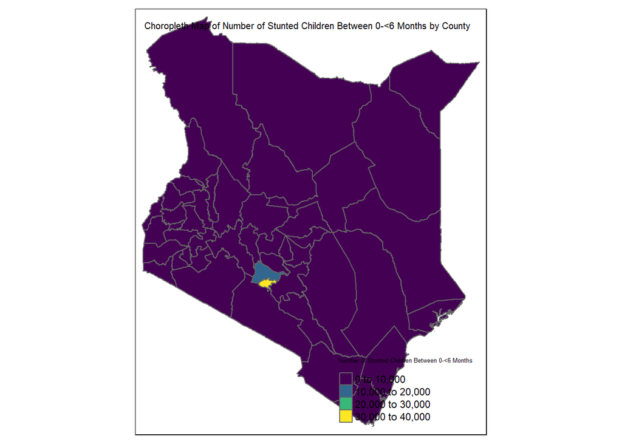

```r
tm_shape(Kenya1_UTM) +tm_borders() +tm_fill("Total Stunted 0-<6 months", title = "Number of Stunted Children Between 0-<6 Months ", palette = "viridis") +tm_layout(title = "Choropleth Map of Number of Stunted Children Between 0-<6 Months by County",legend.position = c("right", "bottom"))
```

### Map Showing the Total Number of Stunted Children Between 24-59 Months by County

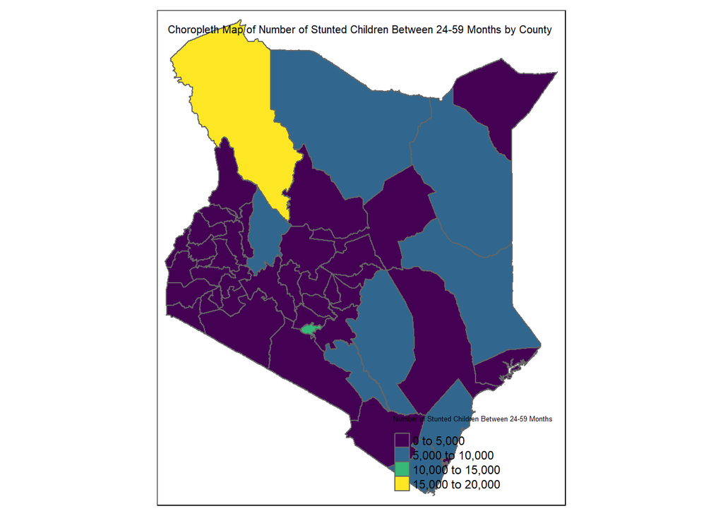

```r
tm_shape(Kenya1_UTM) +tm_borders() +tm_fill("Total Stunted 24-59 Months", title = "Number of Stunted Children Between 24-59 Months ", palette = "viridis") +tm_layout(title = "Choropleth Map of Number of Stunted Children Between 24-59 Months by County",legend.position = c("right", "bottom"))
```

# Research Question

How do the trends in the various child health indicators differ between marginalized and non-marginalized counties in Kenya?

A report by the Commission for Revenue Allocation defines marginalization as a process of social exclusion from the dominant socio-economic, cultural and political structure. The report adds that marginalization is a consequence of a skewed process of the distribution of scarce resources.  
The report determined that the five most marginalized counties in Kenya are Turkana, Marsabit, Mandera, Lamu and Wajir.  
I will use these counties to investigate whether there is a difference in various child health indicators, compared to the other counties.

##Selecting the marginalized counties

```r
mgz<-data%>%filter(county %in% c("Turkana County", "Marsabit County", "Mandera County", "Lamu County", "Wajir County"))
nmg<-data%>%filter(!(county %in% c("Turkana County", "Marsabit County", "Mandera County", "Lamu County", "Wajir County")))
```

## Investigating difference in the total dewormed variable

### Comparing means

```r
mean(mgz$`Total Dewormed`)
```

```
## [1] 7867.113
```

```r
mean(nmg$`Total Dewormed`)
```

```
## [1] 11885.4
```

```r
mean(mgz$`Total Dewormed`)-mean(nmg$`Total Dewormed`)
```

```
## [1] -4018.282
```

The mean for the total number of children dewormed in margialized areas is significantly lower compared to other regions, with a difference of 4018.282.

### t-test

```r
#First we test for normality
shapiro.test(mgz$`Total Dewormed`)
```

```
##
##  Shapiro-Wilk normality test
##
## data:  mgz$`Total Dewormed`
## W = 0.67407, p-value < 2.2e-16
```

```r
shapiro.test(nmg$`Total Dewormed`)
```

```
##
##  Shapiro-Wilk normality test
##
## data:  nmg$`Total Dewormed`
## W = 0.37706, p-value < 2.2e-16
```

```r
t.test(mgz$`Total Dewormed`, nmg$`Total Dewormed`)
```

```
##
##  Welch Two Sample t-test
##
## data:  mgz$`Total Dewormed` and nmg$`Total Dewormed`
## t = -3.5763, df = 448.18, p-value = 0.0003864
## alternative hypothesis: true difference in means is not equal to 0
## 95 percent confidence interval:
##  -6226.439 -1810.125
## sample estimates:
## mean of x mean of y
##  7867.113 11885.395
```

Taking 0.05 to be our level of significance. We see that our p-value is very small, significantly less that 0.05. We therefore reject the null hypothesis(equality of means) and conclude that there is a significant difference between the total number of children dewormed in marginalized and non-marginalized regions.

## Investigating difference in the Acute Malnutrition variable

### Comparing means

```r
mean(mgz$`Acute Malnutrition`, na.rm=TRUE)
```

```
## [1] 441.6333
```

```r
mean(nmg$`Acute Malnutrition`, na.rm=TRUE)
```

```
## [1] 84.8139
```

```r
mean(nmg$`Acute Malnutrition`, na.rm=TRUE)-mean(mgz$`Acute Malnutrition`, na.rm=TRUE)
```

```
## [1] -356.8194
```

The mean for the total number of children suffering from acute malnutrition in margialized areas is significantly higher compared to other regions, with a difference of 356.8194.

### t-test

```r
#First we test for normality
shapiro.test(mgz$`Acute Malnutrition`)
```

```
##
##  Shapiro-Wilk normality test
##
## data:  mgz$`Acute Malnutrition`
## W = 0.61084, p-value = 2.391e-16
```

```r
shapiro.test(nmg$`Acute Malnutrition`)
```

```
##
##  Shapiro-Wilk normality test
##
## data:  nmg$`Acute Malnutrition`
## W = 0.68622, p-value < 2.2e-16
```

```r
t.test(mgz$`Acute Malnutrition`, nmg$`Acute Malnutrition`)
```

```
##
##  Welch Two Sample t-test
##
## data:  mgz$`Acute Malnutrition` and nmg$`Acute Malnutrition`
## t = 6.1658, df = 120.12, p-value = 9.724e-09
## alternative hypothesis: true difference in means is not equal to 0
## 95 percent confidence interval:
##  242.2407 471.3982
## sample estimates:
## mean of x mean of y
##  441.6333   84.8139
```

Taking 0.05 to be our level of significance. We see that our p-value is very small, significantly less that 0.05. We therefore reject the null hypothesis(equality of means) and conclude that there is a significant difference between the number of children suffering from acute malnutrition in marginalized and non-marginalized regions.

## Investigating difference in the stunted 6-23 months variable

### Comparing means

```r
mean(mgz$`stunted 6-23 months`, na.rm=TRUE)
```

```
## [1] 243.8867
```

```r
mean(nmg$`stunted 6-23 months`, na.rm=TRUE)
```

```
## [1] 284.5132
```

```r
mean(mgz$`stunted 6-23 months`, na.rm=TRUE)-mean(nmg$`stunted 6-23 months`, na.rm=TRUE)
```

```
## [1] -40.62654
```

The mean for the total number of children with stunted growth between 6-23 months in margialized areas islower compared to other regions, with a difference of 40.62654.

### t-test

```r
#First we test for normality
shapiro.test(mgz$`stunted 6-23 months`)
```

```
##
##  Shapiro-Wilk normality test
##
## data:  mgz$`stunted 6-23 months`
## W = 0.71883, p-value = 1.317e-15
```

```r
shapiro.test(nmg$`stunted 6-23 months`)
```

```
##
##  Shapiro-Wilk normality test
##
## data:  nmg$`stunted 6-23 months`
## W = 0.61742, p-value < 2.2e-16
```

```r
t.test(mgz$`stunted 6-23 months`, nmg$`stunted 6-23 months`)
```

```
##
##  Welch Two Sample t-test
##
## data:  mgz$`stunted 6-23 months` and nmg$`stunted 6-23 months`
## t = -1.4219, df = 203.92, p-value = 0.1566
## alternative hypothesis: true difference in means is not equal to 0
## 95 percent confidence interval:
##  -96.95961  15.70652
## sample estimates:
## mean of x mean of y
##  243.8867  284.5132
```

Taking 0.05 to be our level of significance. We see that our p-value is larger than 0.05. We therefore fail to reject the null hypothesis(equality of means) and conclude that there is no significant difference between the number of children suffering from stunted growth 6-23 months in marginalized and non-marginalized regions.

## Investigating difference in the stunted 0-<6 months variable

### Comparing means

```r
mean(mgz$`stunted 0-<6 months`, na.rm=TRUE)
```

```
## [1] 81.86897
```

```r
mean(nmg$`stunted 0-<6 months`, na.rm=TRUE)
```

```
## [1] 146.5321
```

```r
mean(mgz$`stunted 0-<6 months`, na.rm=TRUE)-mean(nmg$`stunted 0-<6 months`, na.rm=TRUE)
```

```
## [1] -64.66314
```

The mean for the total number of children with stunted growth between 0-<6 months in margialized areas is lower compared to other regions, with a difference of 64.66314.

### t-test

```r
#First we test for normality
shapiro.test(mgz$`stunted 0-<6 months`)
```

```
##
##  Shapiro-Wilk normality test
##
## data:  mgz$`stunted 0-<6 months`
## W = 0.67638, p-value < 2.2e-16
```

```r
shapiro.test(nmg$`stunted 0-<6 months`)
```

```
##
##  Shapiro-Wilk normality test
##
## data:  nmg$`stunted 0-<6 months`
## W = 0.32273, p-value < 2.2e-16
```

```r
t.test(mgz$`stunted 0-<6 months`, nmg$`stunted 0-<6 months`)
```

```
##
##  Welch Two Sample t-test
##
## data:  mgz$`stunted 0-<6 months` and nmg$`stunted 0-<6 months`
## t = -5.1057, df = 414.41, p-value = 5.034e-07
## alternative hypothesis: true difference in means is not equal to 0
## 95 percent confidence interval:
##  -89.55867 -39.76761
## sample estimates:
## mean of x mean of y
##  81.86897 146.53210
```

Taking 0.05 to be our level of significance. We see that our p-value is less than 0.05. We therefore reject the null hypothesis(equality of means) and conclude that there is a significant difference between the number of children suffering from stunted growth 0-<6 months in marginalized and non-marginalized regions.

## Investigating difference in the stunted 24-59 months variable

### Comparing means

```r
mean(mgz$`stunted 24-59 months`, na.rm=TRUE)
```

```
## [1] 281.6364
```

```r
mean(nmg$`stunted 24-59 months`, na.rm=TRUE)
```

```
## [1] 91.26417
```

```r
mean(mgz$`stunted 24-59 months`, na.rm=TRUE)-mean(nmg$`stunted 24-59 months`, na.rm=TRUE)
```

```
## [1] 190.3722
```

The mean for the total number of children with stunted growth between 24-59 months in margialized areas is significantly higher compared to other regions, with a difference of 190.3722.

### t-test

```r
#First we test for normality
shapiro.test(mgz$`stunted 24-59 months`)
```

```
##
##  Shapiro-Wilk normality test
##
## data:  mgz$`stunted 24-59 months`
## W = 0.72894, p-value = 6.191e-15
```

```r
shapiro.test(nmg$`stunted 24-59 months`)
```

```
##
##  Shapiro-Wilk normality test
##
## data:  nmg$`stunted 24-59 months`
## W = 0.45927, p-value < 2.2e-16
```

```r
t.test(mgz$`stunted 24-59 months`, nmg$`stunted 24-59 months`)
```

```
##
##  Welch Two Sample t-test
##
## data:  mgz$`stunted 24-59 months` and nmg$`stunted 24-59 months`
## t = 6.864, df = 149.91, p-value = 1.656e-10
## alternative hypothesis: true difference in means is not equal to 0
## 95 percent confidence interval:
##  135.5703 245.1741
## sample estimates:
## mean of x mean of y
## 281.63636  91.26417
```

Taking 0.05 to be our level of significance. We see that our p-value is less than 0.05. We therefore reject the null hypothesis(equality of means) and conclude that there is a significant difference between the number of children suffering from stunted growth 24-59 months in marginalized and non-marginalized regions.

## Investigating difference in the diarrhoea cases variable

### Comparing means

```r
mean(mgz$`diarrhoea cases`, na.rm=TRUE)
```

```
## [1] 3889.913
```

```r
mean(nmg$`diarrhoea cases`, na.rm=TRUE)
```

```
## [1] 2685.224
```

```r
mean(mgz$`diarrhoea cases`, na.rm=TRUE)-mean(nmg$`diarrhoea cases`, na.rm=TRUE)
```

```
## [1] 1204.69
```

The mean for the total number of children with diarrhoea cases reported in margialized areas is significantly higher compared to other regions, with a difference of 1204.69.

### t-test

```r
#First we test for normality
shapiro.test(mgz$`diarrhoea cases`)
```

```
##
##  Shapiro-Wilk normality test
##
## data:  mgz$`diarrhoea cases`
## W = 0.90671, p-value = 3.221e-08
```

```r
shapiro.test(nmg$`diarrhoea cases`)
```

```
##
##  Shapiro-Wilk normality test
##
## data:  nmg$`diarrhoea cases`
## W = 0.77876, p-value < 2.2e-16
```

```r
t.test(mgz$`diarrhoea cases`, nmg$`diarrhoea cases`)
```

```
##
##  Welch Two Sample t-test
##
## data:  mgz$`diarrhoea cases` and nmg$`diarrhoea cases`
## t = 5.1091, df = 168.26, p-value = 8.708e-07
## alternative hypothesis: true difference in means is not equal to 0
## 95 percent confidence interval:
##   739.1938 1670.1852
## sample estimates:
## mean of x mean of y
##  3889.913  2685.224
```

Taking 0.05 to be our level of significance. We see that our p-value is less than 0.05. We therefore reject the null hypothesis(equality of means) and conclude that there is a significant difference between the number of children with diarrhoea cases reported in marginalized and non-marginalized regions.

## Investigating difference in the Underweight 0-<6 months variable

### Comparing means

```r
mean(mgz$`Underweight 0-<6 months`, na.rm=TRUE)
```

```
## [1] 149.5267
```

```r
mean(nmg$`Underweight 0-<6 months`, na.rm=TRUE)
```

```
## [1] 232.2738
```

```r
mean(mgz$`Underweight 0-<6 months`, na.rm=TRUE)-mean(nmg$`Underweight 0-<6 months`, na.rm=TRUE)
```

```
## [1] -82.74714
```

The mean for the total number of children underweight between 0-6 months reported in marginalized areas is lower compared to other regions, with a difference of 82.74714.

### t-test

```r
#First we test for normality
shapiro.test(mgz$`Underweight 0-<6 months`)
```

```
##
##  Shapiro-Wilk normality test
##
## data:  mgz$`Underweight 0-<6 months`
## W = 0.88259, p-value = 1.539e-09
```

```r
shapiro.test(nmg$`Underweight 0-<6 months`)
```

```
##
##  Shapiro-Wilk normality test
##
## data:  nmg$`Underweight 0-<6 months`
## W = 0.68948, p-value < 2.2e-16
```

```r
t.test(mgz$`Underweight 0-<6 months`, nmg$`Underweight 0-<6 months`)
```

```
##
##  Welch Two Sample t-test
##
## data:  mgz$`Underweight 0-<6 months` and nmg$`Underweight 0-<6 months`
## t = -6.6555, df = 287.06, p-value = 1.429e-10
## alternative hypothesis: true difference in means is not equal to 0
## 95 percent confidence interval:
##  -107.21821  -58.27608
## sample estimates:
## mean of x mean of y
##  149.5267  232.2738
```

Taking 0.05 to be our level of significance. We see that our p-value is less than 0.05. We therefore reject the null hypothesis(equality of means) and conclude that there is a significant difference between the number of children underweight between 0-6 months in marginalized and non-marginalized regions.

## Investigating difference in the Underweight 6-23 months variable

### Comparing means

```r
mean(mgz$`Underweight 6-23 months`, na.rm=TRUE)
```

```
## [1] 872.3467
```

```r
mean(nmg$`Underweight 6-23 months`, na.rm=TRUE)
```

```
## [1] 626.0587
```

```r
mean(mgz$`Underweight 6-23 months`, na.rm=TRUE)-mean(nmg$`Underweight 6-23 months`, na.rm=TRUE)
```

```
## [1] 246.288
```

The mean for the total number of children underweight between 6-23 months reported in marginalized areas is higher compared to other regions, with a difference of 246.288.

### t-test

```r
#First we test for normality
shapiro.test(mgz$`Underweight 6-23 months`)
```

```
##
##  Shapiro-Wilk normality test
##
## data:  mgz$`Underweight 6-23 months`
## W = 0.76245, p-value = 2.637e-14
```

```r
shapiro.test(nmg$`Underweight 6-23 months`)
```

```
##
##  Shapiro-Wilk normality test
##
## data:  nmg$`Underweight 6-23 months`
## W = 0.71472, p-value < 2.2e-16
```

```r
t.test(mgz$`Underweight 6-23 months`, nmg$`Underweight 6-23 months`)
```

```
##
##  Welch Two Sample t-test
##
## data:  mgz$`Underweight 6-23 months` and nmg$`Underweight 6-23 months`
## t = 3.1707, df = 165.66, p-value = 0.001812
## alternative hypothesis: true difference in means is not equal to 0
## 95 percent confidence interval:
##   92.92295 399.65308
## sample estimates:
## mean of x mean of y
##  872.3467  626.0587
```

Taking 0.05 to be our level of significance. We see that our p-value is less than 0.05. We therefore reject the null hypothesis(equality of means) and conclude that there is a significant difference between the number of children underweight between 6-23 months in marginalized and non-marginalized regions.

## Investigating difference in the Underweight 24-59 months variable

### Comparing means

```r
mean(mgz$`Underweight 24-59 Months`, na.rm=TRUE)
```

```
## [1] 1108.12
```

```r
mean(nmg$`Underweight 24-59 Months`, na.rm=TRUE)
```

```
## [1] 210.2155
```

```r
mean(mgz$`Underweight 24-59 Months`, na.rm=TRUE)-mean(nmg$`Underweight 24-59 Months`, na.rm=TRUE)
```

```
## [1] 897.9045
```

The mean for the total number of children underweight between 24-59 months reported in marginalized areas is higher compared to other regions, with a difference of 897.9045.

### t-test

```r
#First we test for normality
shapiro.test(mgz$`Underweight 24-59 Months`)
```

```
##
##  Shapiro-Wilk normality test
##
## data:  mgz$`Underweight 24-59 Months`
## W = 0.8272, p-value = 5.105e-12
```

```r
shapiro.test(nmg$`Underweight 24-59 Months`)
```

```
##
##  Shapiro-Wilk normality test
##
## data:  nmg$`Underweight 24-59 Months`
## W = 0.58928, p-value < 2.2e-16
```

```r
t.test(mgz$`Underweight 24-59 Months`, nmg$`Underweight 24-59 Months`)
```

```
##
##  Welch Two Sample t-test
##
## data:  mgz$`Underweight 24-59 Months` and nmg$`Underweight 24-59 Months`
## t = 9.9154, df = 151.76, p-value < 2.2e-16
## alternative hypothesis: true difference in means is not equal to 0
## 95 percent confidence interval:
##   718.9905 1076.8185
## sample estimates:
## mean of x mean of y
## 1108.1200  210.2155
```

Taking 0.05 to be our level of significance. We see that our p-value is less than 0.05. We therefore reject the null hypothesis(equality of means) and conclude that there is a significant difference between the number of children underweight between 24-59 months in marginalized and non-marginalized regions.

##Findings. My research question prompted me to investigate how the various child health indicators difer betwee marginalized and non-marginalized counties.  
I decided to do t-tests for the numerical variables, having split the counties into two categories: marginalized and non-marginalized.  
The results showed that there are inndeed differences in child health inndicators across the two groups of counties. Marginalized counties generally had poor numbers when compared to the counties. For instance, when considering the Total Dewormed variable, marginalized areas had a lower number compared to the other counties. This difference is significant.  
For the acute malnutrition variable, marginalized counties had higher children reported, compared to the non-marginalized counties. The difference was significant.  
For the stunted 6-23 months variable, non-marginalized counties actually had a higher tally than the marginalized ones, but this difference was not significant.  
For the stunted 0-6 months variable, non-marginalized counties also had higher tallies, and the difference in this case was significant.  
For the stunted 24-59 months variable, marginalized counties recorded significantly higher figures compared to the rest, and this difference was statistically significant.  
For the diarrhoea cases variable, marginalized counties recorded higher figures again, with the difference being statistically significant.  
For the underweight 0-<6 months variable, the non-marginalized counties posted higher figures, and this result proved to be statistically significant.  
For the underweight 6-23 months variable, marginalized counties had more cases reported, and this result was also statistically significant.  
For the underweight 24-59 months variable, the marginalized counties again posted higher tallies than the non-marginalized ones, with the result also being statistically significant.

##Conclusion. While the non-marginalized counties also showed cause for concern with regard to various child health indicators compared to the marginalized counties, it is evident that marginalized counties indeed suffer heavily, and as a result more work must be done in such areas, so as to bridge the gap between the two groups of counties.

# Adendum

##Running linear regression to depict the relationships between some of the variables

```r
mdl1<-lm(`Acute Malnutrition`~., data=data[, -c(1,2)])
summary(mdl1)
```

```
##
## Call:
## lm(formula = `Acute Malnutrition` ~ ., data = data[, -c(1, 2)])
##
## Residuals:
##    Min     1Q Median     3Q    Max
## -575.4  -74.5  -26.9   27.0 3375.0
##
## Coefficients:
##                              Estimate Std. Error t value Pr(>|t|)
## (Intercept)                -8.261e+04  2.012e+04  -4.105 4.35e-05 ***
## `Total Dewormed`            2.469e-04  3.115e-04   0.793  0.42817
## `stunted 6-23 months`      -1.617e-01  3.024e-02  -5.345 1.11e-07 ***
## `stunted 0-<6 months`      -3.998e-03  3.075e-02  -0.130  0.89657
## `stunted 24-59 months`     -2.196e-01  4.980e-02  -4.409 1.15e-05 ***
## `diarrhoea cases`           1.018e-02  4.677e-03   2.178  0.02965 *
## `Underweight 0-<6 months`   1.128e-01  5.280e-02   2.136  0.03294 *
## `Underweight 6-23 months`   6.698e-02  2.552e-02   2.624  0.00881 **
## `Underweight 24-59 Months`  2.013e-01  1.987e-02  10.128  < 2e-16 ***
## monthAug                   -4.104e+00  3.493e+01  -0.118  0.90649
## monthDec                    3.888e+01  3.483e+01   1.116  0.26455
## monthFeb                    3.875e+01  3.070e+01   1.262  0.20718
## monthJan                   -1.734e+01  3.119e+01  -0.556  0.57830
## monthJul                    2.020e+01  3.561e+01   0.567  0.57070
## monthJun                    1.779e+01  3.192e+01   0.557  0.57750
## monthMar                    3.753e+01  3.048e+01   1.231  0.21846
## monthMay                   -1.556e+01  3.128e+01  -0.497  0.61899
## monthNov                    3.234e+01  3.571e+01   0.906  0.36529
## monthOct                    9.024e+01  3.510e+01   2.571  0.01028 *
## monthSep                    4.191e+01  3.479e+01   1.205  0.22860
## year                        4.085e+01  9.951e+00   4.105 4.36e-05 ***
## ---
## Signif. codes:  0 '***' 0.001 '**' 0.01 '*' 0.05 '.' 0.1 ' ' 1
##
## Residual standard error: 221.7 on 1027 degrees of freedom
##   (362 observations deleted due to missingness)
## Multiple R-squared:  0.2659, Adjusted R-squared:  0.2516
## F-statistic:  18.6 on 20 and 1027 DF,  p-value: < 2.2e-16
```